# Policing and Corrections

CRIM 100

# Policing

## Detroit

[video not shown]

## Key features of public police:

- Legally authorized to use coercive force.
- Non-military, but embrace militaristic-bureaucratic hierarchical chain of command

## Policing as a concept

- Shift from police “organization” to policing “process”
  - Considers individuals and entities outside police organizations that intervene
- Public vs private policing

## Forces shaping policing (1/2)

- Recognition that police agencies and the cjs inability to prevent crime and guarantee security by themselves
- Cost-saving resource allocation measures
- Widespread mobilization of community policing
  - *Responsibilization strategies* activate informal social control agents
- Proliferation of private policing
- Technology advancements and data availability

## Forces shaping policing (2/2)

- Acknowledgement that modern human resource management not compatible with military style structure
- Impact of high levels of fear in the midst of consistent crime reduction
  - Garland’s crime complex:
    - High crime rates are a given
    - Widespread and intense emotional investment in crime
    - Politization of crime
    - Public policy dominated by concern over victims & public safety
    - Perception of CJ ineffectiveness
    - Large market for security
    - Crime awareness

## Levels of Policing in Canada

- Federal
  - 6.7% of police officers in Canada
  - RCMP
- Provincial
  - 15% of police officers
  - Independent provincial police forces (Ontario, Quebec & Newfoundland) + RCMP provincial contracts
- Municipal
  - 66% of police officers
  - Independent police forces (89%) + RCMP municipal contracts (10%)
- Regional policing
  - Option for adjacent municipalities to amalgamate their individual police departments into one large police service

## First Nations

- Provinces have jurisdiction over the “administration of justice” & federal government has authority over “Indians and Lands reserved for the Indians”
- First Nations Policing Program (FNPP)
  - Aimed at improving quality of policing services
  - The federal government, through Public Safety Canada, negotiates cost-sharing agreements with the provinces
  - Two main types of policing agreements:
    - Self-administered Agreements. Cmmunity manages its own police service
    - Community Tripartite Agreements. Dedicated contingent of officers from an existing police service.

## Private policing

- Regulated by provincial licensing and registration system
- Concerns:
  - Violation of individual rights
  - Continued blurring between private & public policing

# Corrections

## Ontario’s correctional issues

[video not shown]

## Sentences in Canada

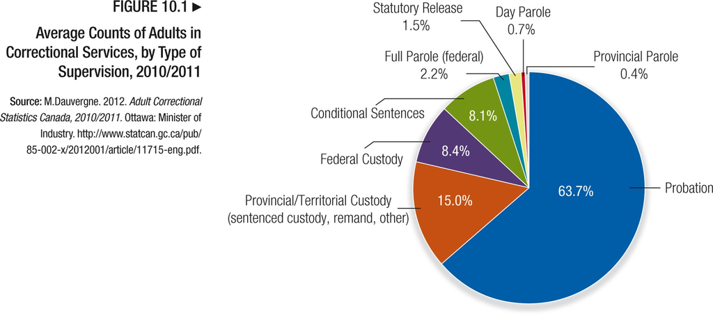

## Organization of the correctional system

- Provincial institutions
  - Sentences of 2 years less 1 day
- Federal institutions
  - Sentence of 2 years or more
  - Correctional Service Canada (CSC)

## Aboriginal Offenders

- Overrepresentation of aboriginals in the correctional system
- Gladue decision
  - A decision by the SCC that held that when a term of incarceration would normally be imposed, judges must consider the unique circumstances of Aboriginal people

## Special Inmate Populations

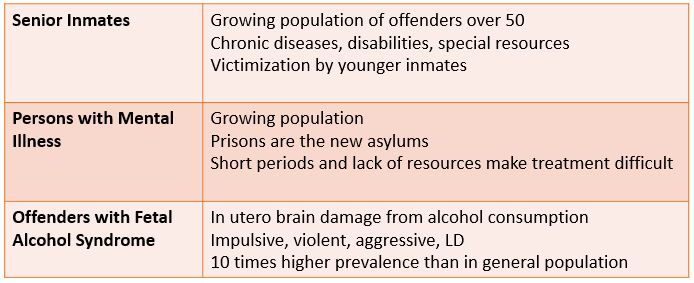

## Other challenges

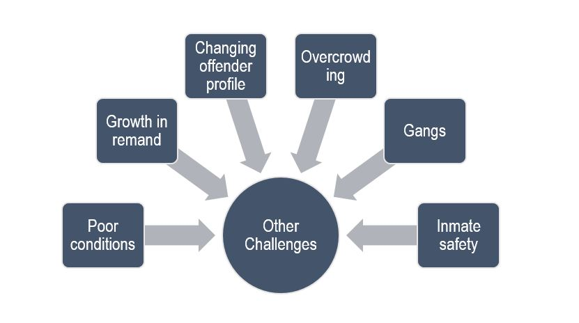

## Inmate Social System

- Inmate Subculture: Patterns of interaction and the relationships that exist among inmates
- Prisonization: Process by which inmates become socialized into the norms, values, and culture of the prison
- Institutionalization: Inmates who have become prisonized to such a degree that they are unable to function in the outside free community

## Correctional programs

- Upon admission, inmates assessed and a correctional plan is developed
  - Plan outlines relevant programs and activities
- Programs include: Living skills, violence prevention, substance abuse prevention, family violence prevention, sex offender treatment, employment readiness
- Poor access to programs
- Rehabilitative and treatment programs from the CSC are among the best in the world.

# Important content

## Key terms

- Public and private policing
- Responsibilization strategies
- Crime complex
- Levels of police
- Federal and provincial institutions
- Gladue decision
- Special inmate populations
- Inmate subculture
- Prisionization
- Institucionalization
- Harm reduction